# Task 2: ChIP-seq data analysis

## Master Notebook: supporting report

Comparative & Regulatory Genomics - [I0U29a] | Task 2 - ChIP-seq data analysis | Antoine Ruzette **r0829308** | 19.12.2021

Based on the ChIP-seq jupyter notebook from Prof. Stein Aerts.

## Introduction and context: skeletal muscle metabolism regulation by the Six1 TF

In this report, the quality control, mapping and function analyis of publicly available ChIP-seq data was performed. The data used were generated through the research project related to the following paper. The data were retrieved from the GEO database from NCBI and can be accessed through the following SRR number: [SRR14711117](https://www.ncbi.nlm.nih.gov/sra?term=SRX11049116).

*Girgis J, Yang D, Chakroun I, Liu Y, Blais A. Six1 promotes skeletal muscle thyroid hormone response through regulation of the MCT10 transporter. Skelet Muscle. 2021 Nov 19;11(1):26. doi: 10.1186/s13395-021-00281-6. PMID: 34809717; PMCID: PMC8607597.*

The study investigates the identification of the binding sites of the Six1 transcription factor in primary myoblasts and myotubes of mice using ChIP-sequencing. We wil focus our analysis on the primary myoblastic cells (MB). Six1 is a transcription factor that is involved in the regulation of cell proliferation, apoptosis and embryonic development and plays an important role in the development of several organs, including kidney, muscle and inner ear. (Reference: [UniProt](https://www.uniprot.org/uniprot/Q62231))

It is known that the Six1 transcription factor is a homeodomain protein involved in controlling gene expression during embryonic development. Six 1 establishes gene expression profiles that enable skeletal myogenesis and nephrogenesis, among others. ([Reference: *Yubing Liu et.al*](https://pubmed.ncbi.nlm.nih.gov/22730291/#:~:text=The%20Six1%20transcription%20factor%20is%20a%20homeodomain%20protein,that%20enable%20skeletal%20myogenesis%20and%20nephrogenesis%2C%20among%20others.) )

From the aforementioned paper and using [UniProt](https://www.uniprot.org/uniprot/Q62231), we can define our control genes:

- The thyroid transporter MCT10 is under direct transcriptional control of Six1 in adult skeletal muscle. **Slc16a10** encodes the MCT10 transmembrane transporter.
- Six1 binds the 5'-TCA[AG][AG]TTNC-3' motif present in the MEF3 element in the **MYOG** promoter
- Six1 acts as activator of the **IGFBP5** promoter, probably coactivated by EYA2. IGFBP5 is a protein coding gene.

Thus, we will be tracking these three as control genes: Slc16a10 (Chr10), MYOG (Chr1) and IGFBP5 (Chr1).

## ChIP-seq Analysis

The main steps and results of the notebook:`Notebook_ChIP-seq_AntoineRuzette`are presented here. To see the code and the results in details, please consult the corresponding jupyter notebook.

As explained during *Regulatory Genomics* classes, the quality control of data is done via FASTQC. Depending on the output of the check, we can decide wether or not we continue with the present data sets. We focus on three quality metrics, namely per base sequence quality, sequences duplication levels and overrepresented sequences.

- The per base sequence quality report plots the distribution of quality scores per bp position
- The sequences duplication levels report indicates how the reads are unique in the library
- The overrepresented sequences report checks for reads that are represented for more than 0.1% in the whole library

### Quality Control (QC)

#### **For the ChIP-seq data set: SRR14711117_1.fastq**

##### Per base sequence

The per base sequence quality of the data set presented good results and passed that first control.

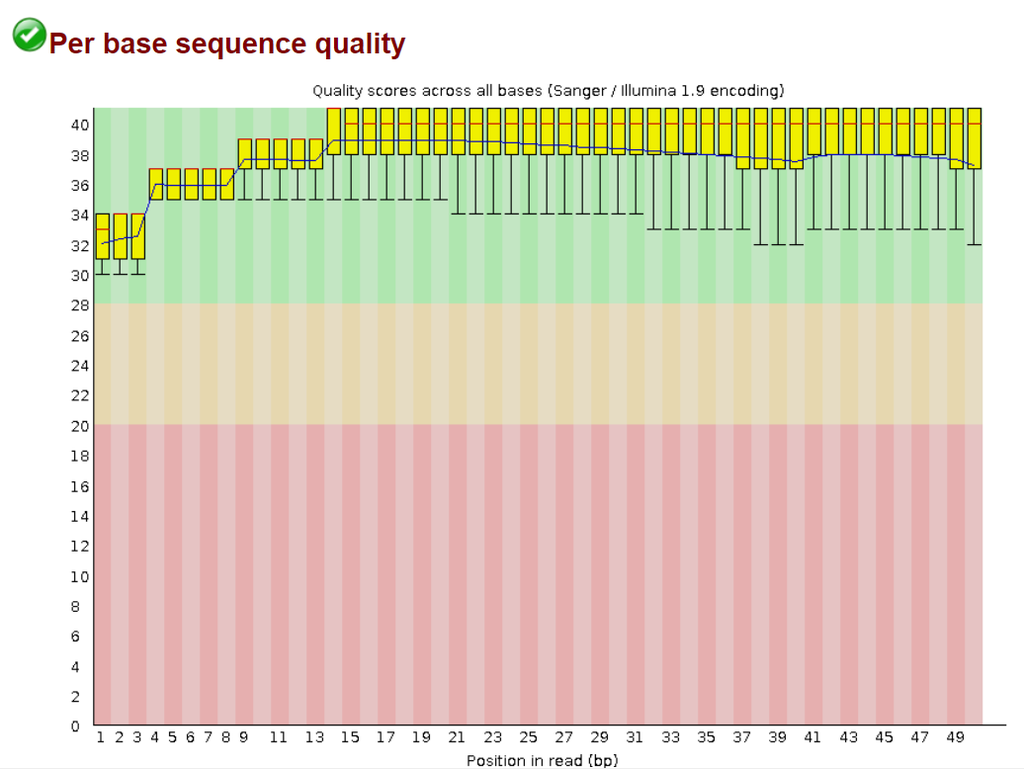

##### Sequence duplication levels

The sequence duplication levels were reported as good and passed that second control.

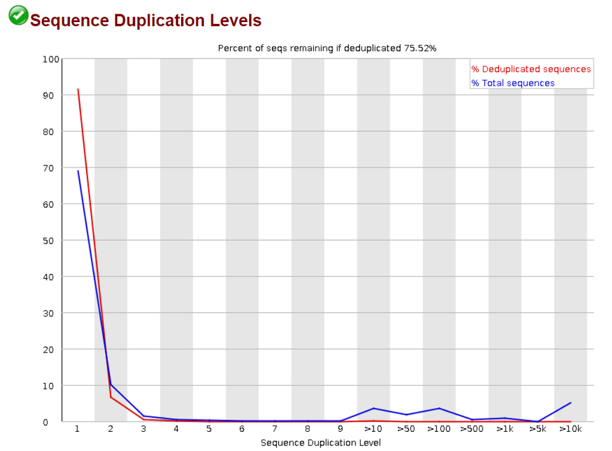

##### Overrepresented sequences

Lastly, we look at sequences that might be overrepresented among the library. Three warnings were reported in the FastQC report, for the following sequences:

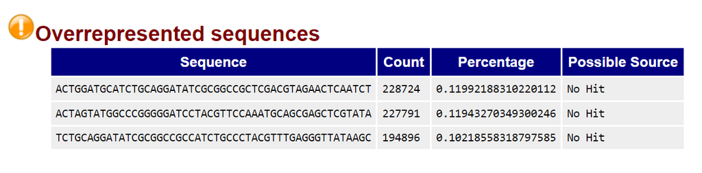

#### **For the input data set: SRR14711120_1.fastq**

##### Per base sequence

The per base sequence quality of the data set presented good results and passed that first control.

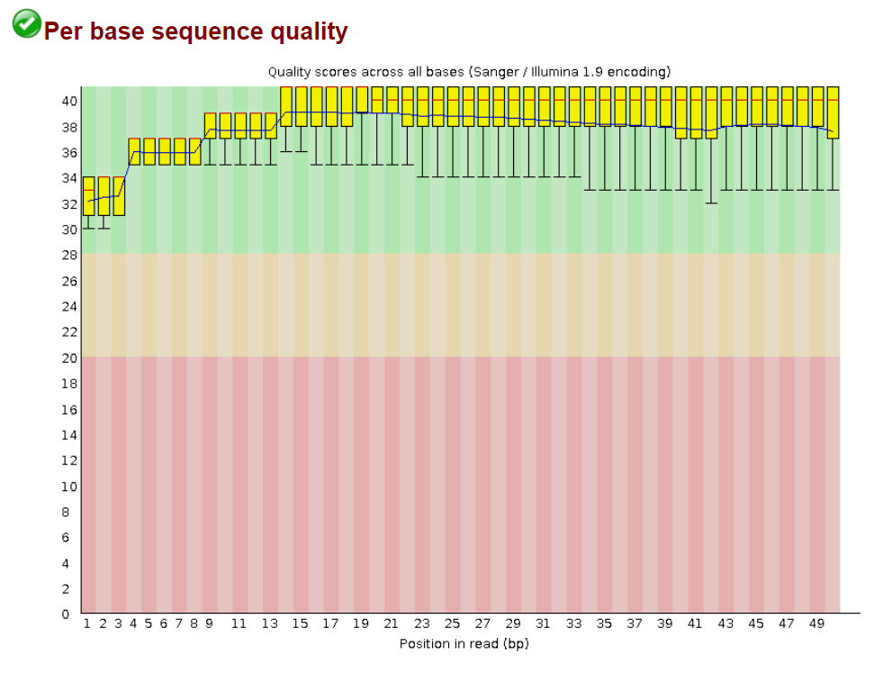

##### Sequence duplication levels

The sequence duplication levels were reported as good and passed that second control.

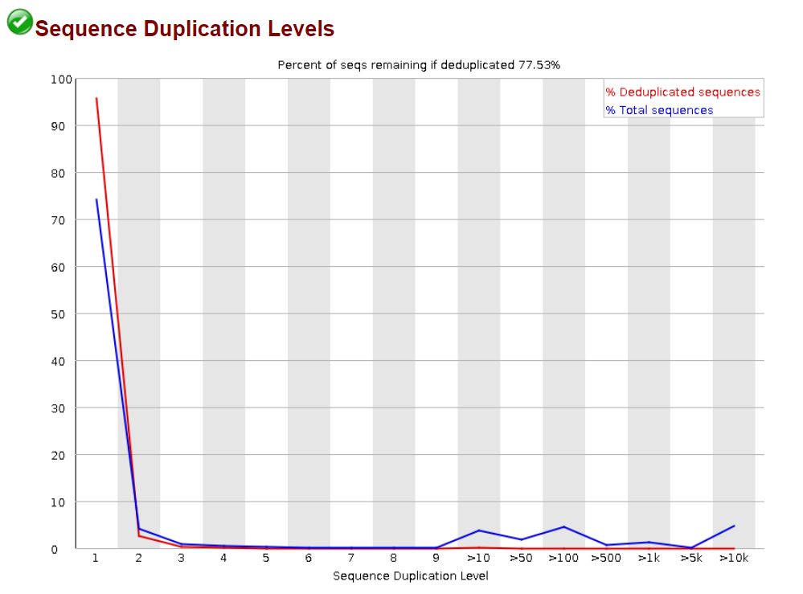

##### Overrepresented sequences

Lastly, we look at sequences that might be overrepresented among the library. No sequences were reported as overrepresented.

Based on the results of the Quality Control, both data sets passed the test. Therefore, we decide to go on to the next step, that is the aligmnent of the reads.

### Alignment of the ChIP-seq reads to the mouse genome

Reads were mapped to the mouse genome`mm10`using bowtie2. Out of 190.727.492 reads, 96.42% were mapped to the reference genome. The mapped reads were saved to a SAM file. The alignment rate is very good.

Note that in the research experiment from the paper, they aligned the reads to the`mm9`genome.

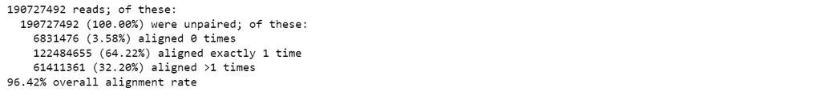

We can check the SAM output file, illustrated below. It indicates the ID, the position and the quality of the mapping of each read.

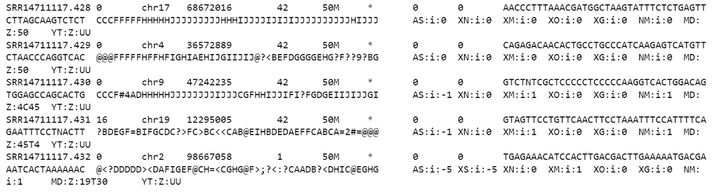

In order to visualize the data using IGV, the SAM files were compressed, transformed to BAM files and sorted, using samtools. It returns much smaller files, which were then indexed using the`samtools index`function.

Let's check in IGV the alignment of the control genes. We observe that many reads were mapped, some forming accumulations in certain parts of the control genes. However, these enriched regions cannot be called peaks yet.

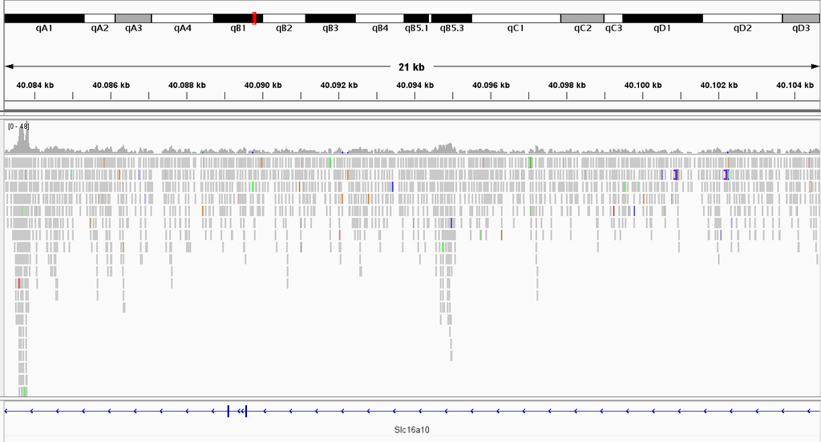

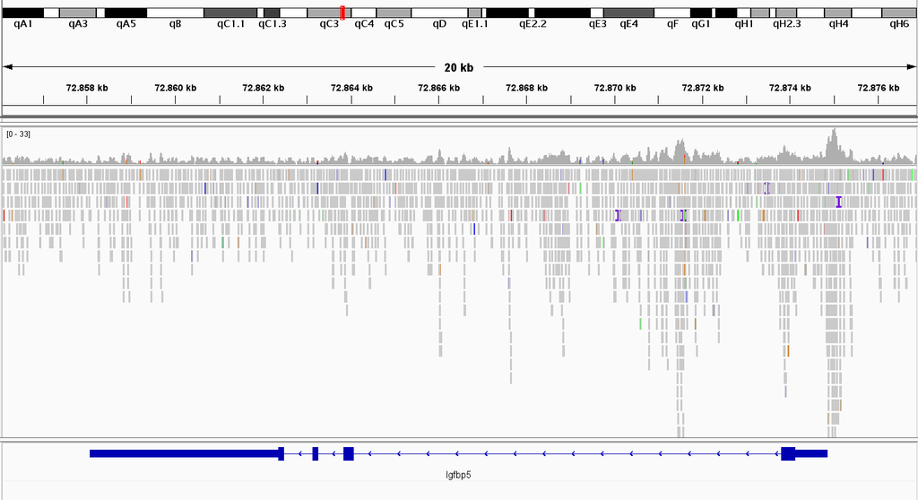

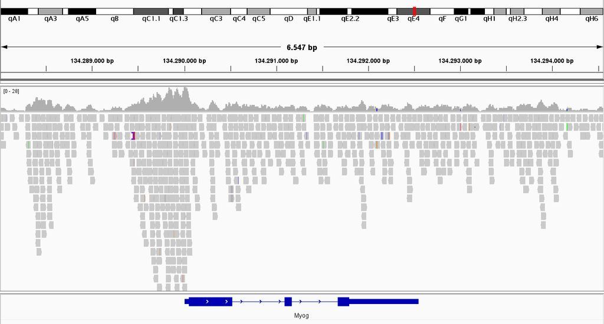

### Genome-wide coverage plots

Before generating proper peaks, we can take a look at the BigWig (.bw) file that was computed from the sorted BAM file. It allow to see the coverage plots in a visualizer such as IGV.

The following plots indicate potential peak regions. For Slc16a10, it is clear that some high coverage regions could turn into peaks. However, for IGFBP5 and MYOG, it is not that clear. IGFBP5 still shows some high density regions.

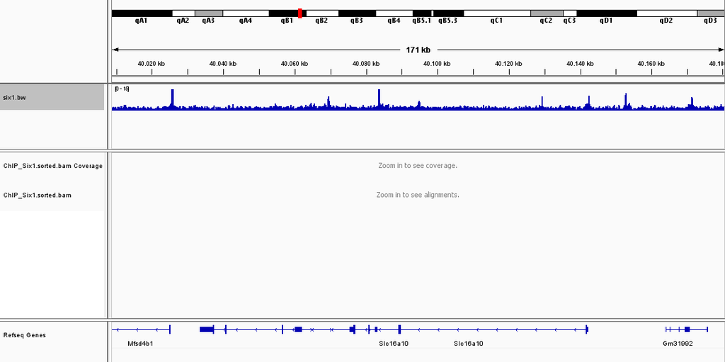

Zoom into the potential peak at 40.084kb:

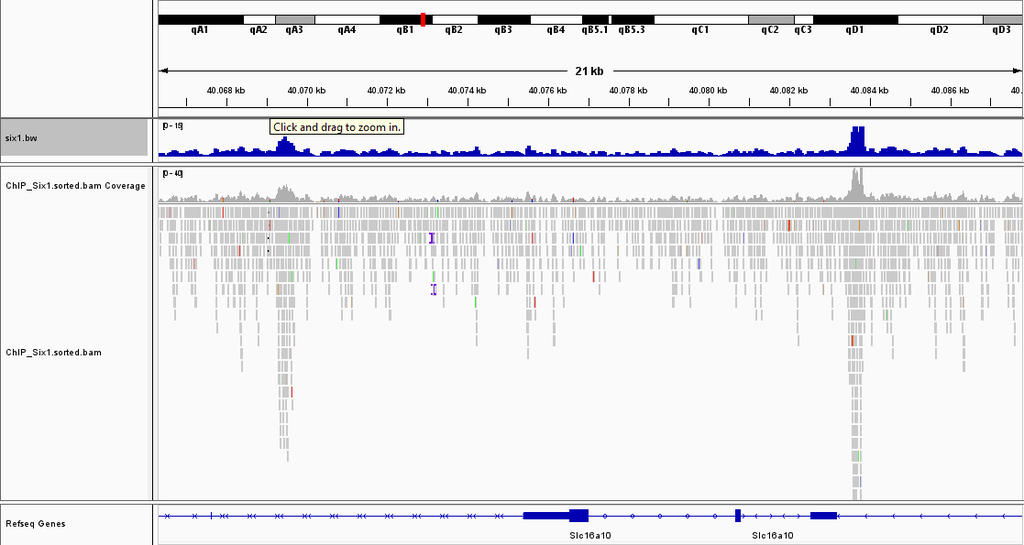

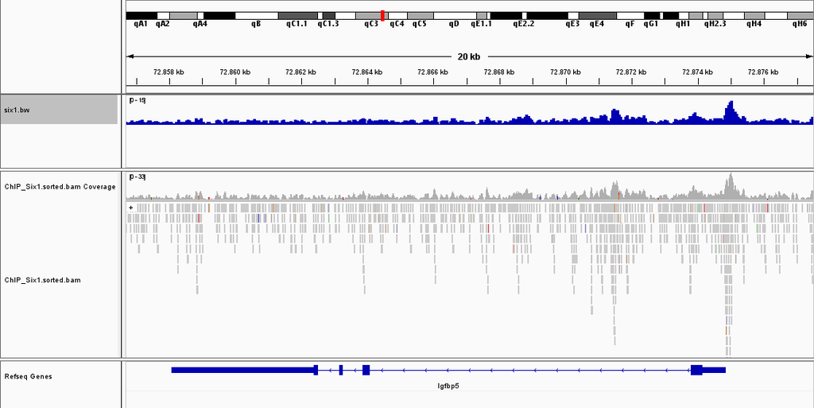

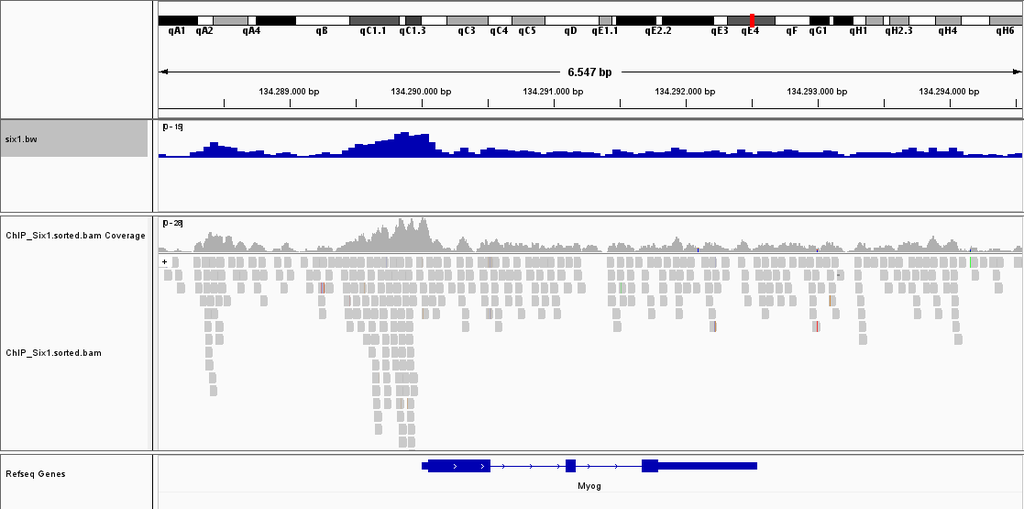

### Peak Calling

We will use a peak calling method to identify genomic areas that have been enriched with aligned reads as a consequence of protein-DNA interaction.

By using the peak calling software`macs2`, we will not naively select regions of highly mapped reads as peaks, but instead take advantage of the strand shifts to retrieve the appropriate peaks.

Once it is done,`macs2`generates 4 files, one of them is called`six_1_peaks.narrowPeak`. It contains all the called peaks.

Using a q-value threshold of 0.5, 212.140 peaks are retained by macs2. We can see that several peaks are picked up in the control genes. A major one is the is the `six_1_peak_17106` that has a q-value of 10e-56.

This is too much to analyze, so we will instead sort the file based on the q-value, and select the first 10.000 peaks to analyze. We finally optain the file `head10000.sorted.six1_peaks.narrowPeak`. This file can be downloaded and visualized on IGV.

*Note on the q-value threshold:*

The initial plan was to start with a relaxed q-value threshold of 0.5. Then, we would refine the threshold to 0.05 and 0.01 to compare the called peaks between those different thresholds. Unfortunetaly, running`macs2`was a real trouble and would only compute the .peaks file one time out of a total of 10 runs (of almost 15 hours each). The problem was often linked to memory errors or different version of`macs2`needed. Thus, we had to move on with the first q-value cutoff of 0.5 which is of course a way too relaxed threshold. By the way, it is illusrated by the load of peaks visualized in IGV.

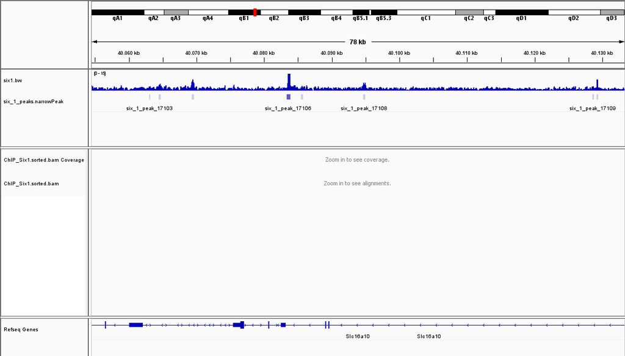

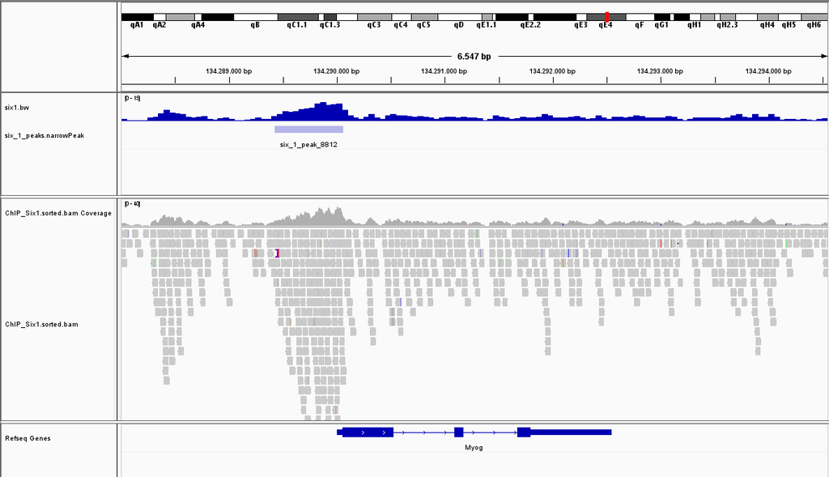

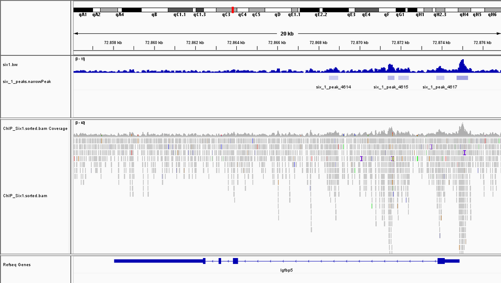

Finally, we generated a .bed file by collecting the 3 first column of our .narrowPeak file. From that file, we can create a matrix of the BigWig signal over the peaks. This allos us to calculate the BigWig signal, 2000 bp upstream and downstream of the center of the peaks, and determine the coverage on these intervals.

From that matrix, we can generate a heatmap plot. It allows us to have a visual distribution of the coverage on the called peaks. It also shows the dessimilarity between peak heights:

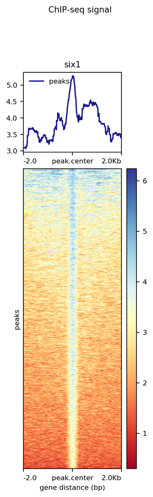

### Motif Analysis

#### RSAT

The first tool that we will utilize is RSAT, it can be used for motif discovery. As we have too much peaks that were picked up by macs2, we sorted the .narrowPeak file by q-value and took the first 10.000 peaks. Here, by using ChIPseq peak motifs, we take the peaks as input in the form of a .fasta file. To get this fasta file, we fedched the sequences using UCSC, by uploading the corresponding .bed file (`six1_10k_peaks.bed`).

To discover motifs in the sequences gathered in the .fasta file, we will be looking for words that are present in greater number than what we could expect by chance. To put it in other words, we are looking for the number of time a motif occurs in those sequences.

The results are presented below. The first table shows the frequencies of nucleotides and dinucleotides from our sequences. All of the nucleotides have about the same frequency (which is not the case in the genome), but some dinucleotides are depleted, such as CG, which is also the case in the genome.

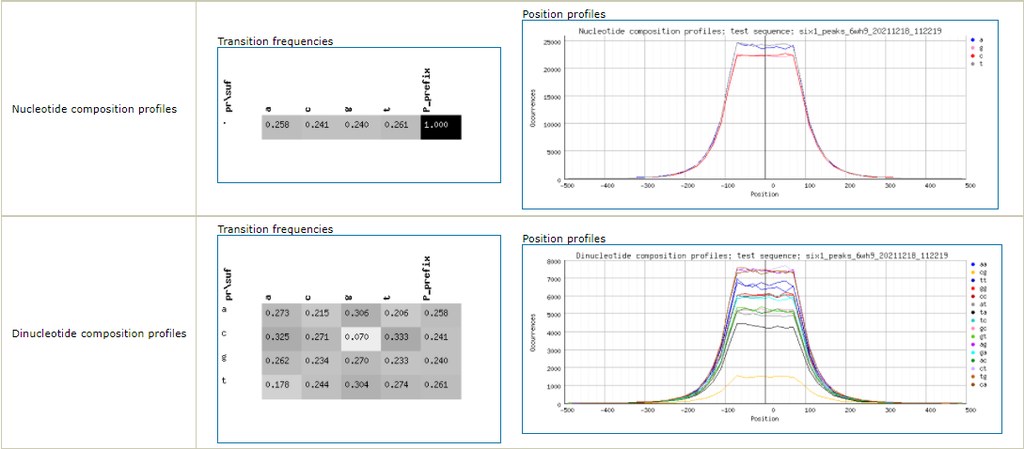

We then optain a summary of all the motifs discovered:

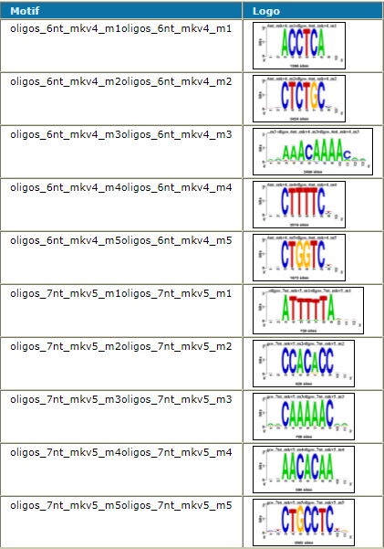

Overall, most of the match occurs in the center of the peak, which is a good sign. The following figure in a zoom in the resuls for the motif 1: ...ACCTCA...

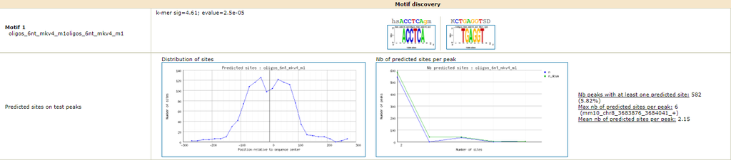

#### PVM and track enrichment using i-CisTarget

Next to de novo motif enrichment, which we did above with RSAT, we can also ask whether the Six1 ChIP-seq peaks we found are enriched for matches to known PSSMs (PWMs) from PSSM databases like JASPAR, TRANFAC, cis-bp, HOCOMOCO, etc.

While RSAT was count based, i-cisTarget is rank based. The results can be retrieved [here](https://gbiomed.kuleuven.be/apps/lcb/i-cisTarget/reports/c3d9385b3f0f8b53b2ec5072f0a211f72a4478fc/report.html).

From that algorithm, we get a list of motifs that are enriched:

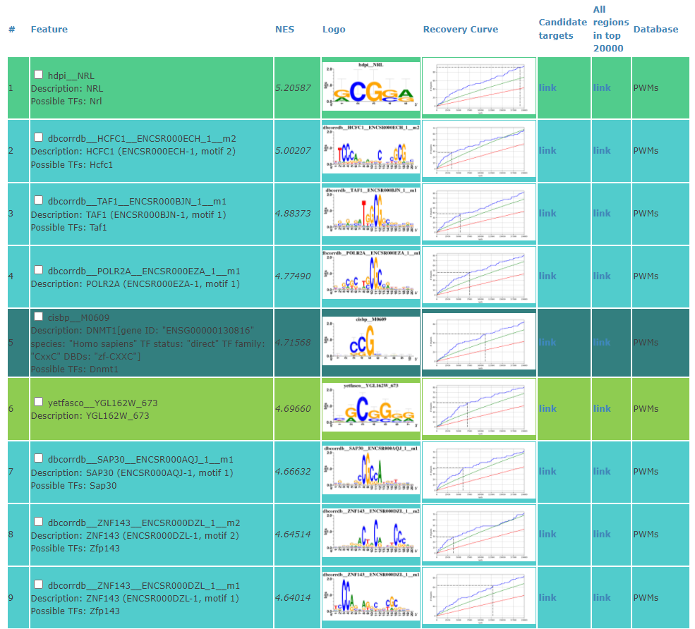

Unfortunately, none lists Six1 as a possible TF, but we can have a closer look to the first motif, which shows different result than for the previous analysis:

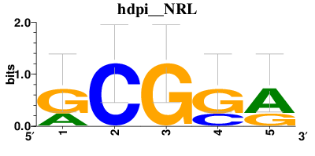

We can also study the following graph, which is called a recovery curve where the red line represent the mean, and the green one is 2 standard deviation of the mean:

- On the x axis are the candidate regions of the genome, ranked by the above motif.
- On the y axis are the number of found input regions.

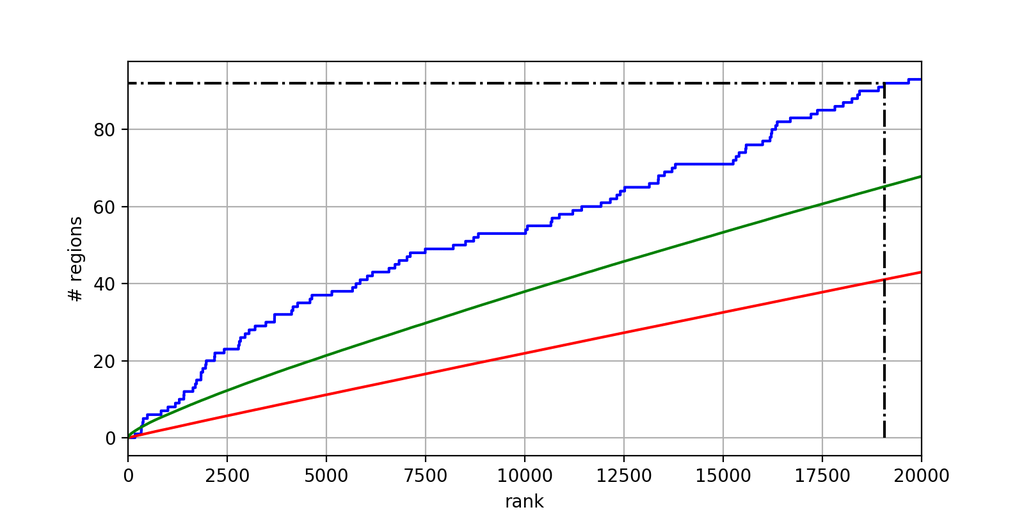

Based on that, we know that we have 92 significantly highly ranked regions out of the original .bed file. We can visualize the a couple of them:

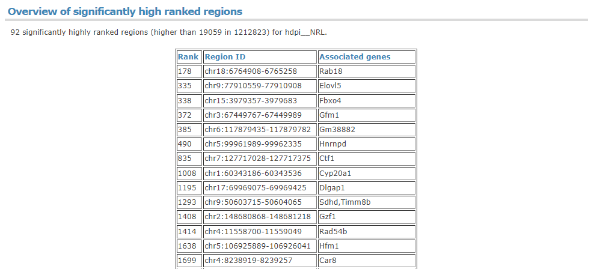

Unfortunately, none of the control genes (Slc16a10, MYOG and IGFBP5) can be found as an associated gene to the significantly high ranked list.

### Link peaks to gene

Until now, we found binding sequences. Nothing yet is said about their possible functions. We will now be looking at potential biological processes that occur at the binding sequences near our peaks. This is what we will try to assess by using the GREAT tool.

We first run GREAT with the direct and indirect peaks. The results of GO enriched terms are shown below:

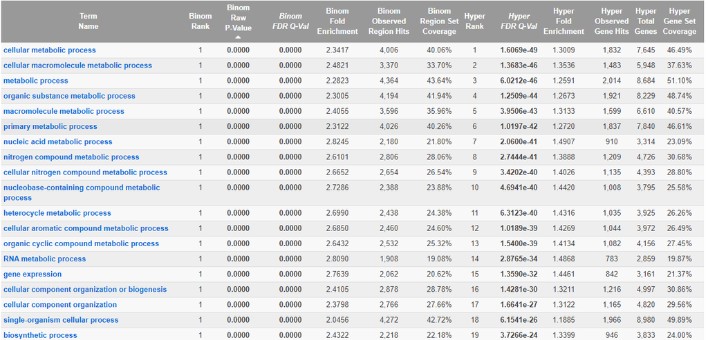

We notice that the majority of GO terms are associated with metabolic processes. Additionally, we see that two GO terms is associated with the cellular component organization. It makes sense since we know that Six1 TF regulates cell proliferation and embyonic development.

Interestingly, human phenotypes include abnormality of skeletal morphology and skeletal system. The latter may confirm the role of Six1 TF in the regulation of the skeletal muscle metabolism.

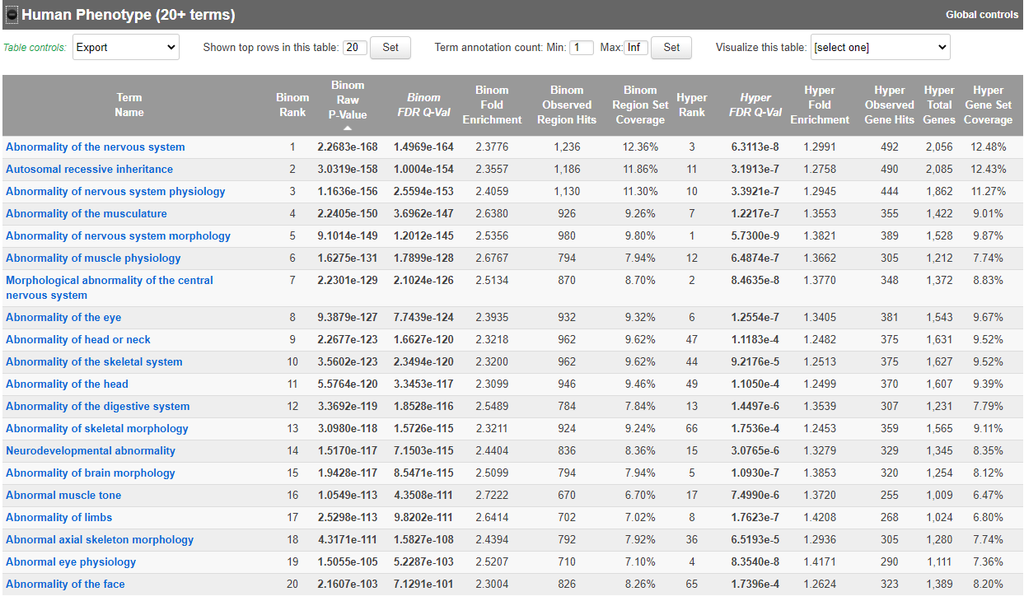

Secondly, we run GREAT on the 92 direct peaks. No GO terms were retrieved.

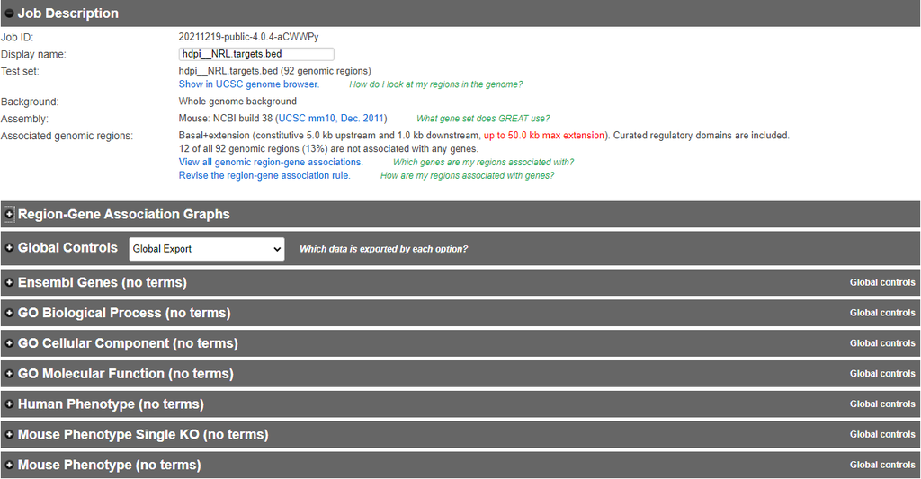

### String tool

When using the 92 high ranked regions (direct targets), the following network is produced by the String tool:

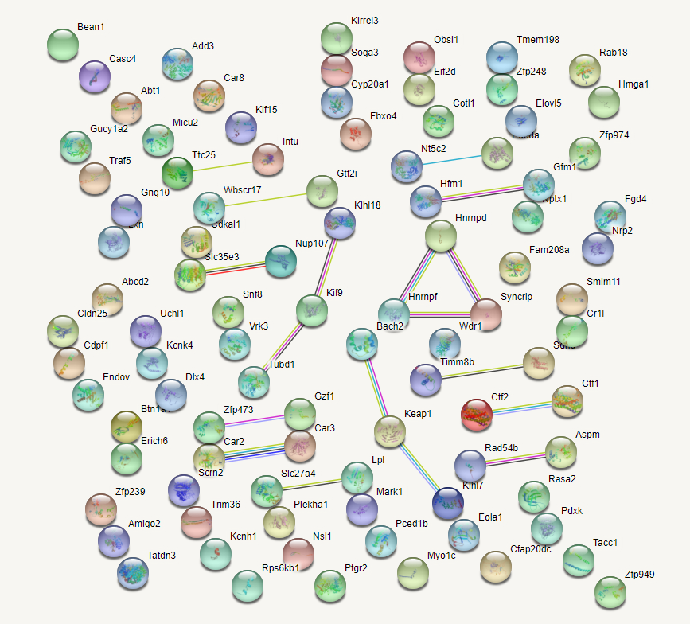

### Conclusion

In conclusion, in the report we have studied the Six1 transcription factor ChIPseq data of myoblastic cells. First, a Quality Control report of the original data and a mapping of the read was done. Then, we moved on to peak calling, motif discovery and target gene analysis.

As we used different data for the RNAseq and ChIPseq project, no conclusion between the two can be drawn.